# Statistics and DataAnalysis

2024-03-03

# 1 Background

## 1.1 Exploratory Data Analysis

**what is the data analysis workflow?**

Hypothesis to investigate/Phonemena to study –> Design the experiment –> Collect data,do the experiment –> Perform exploratory data analysis(can directly to the last step) –> Propose statistical model –> Fit the model –> Validate the model –> Summarize results,and conclude

**Descriptive statistics**

- number of observations
- number and type of variables
- number of missing values
- (empirical) mean,truncated/trimmed mean,median
- quantiles and quartiles
- variance,standard deviation, and interquartile range(third quartile minus the first quartile)

**Types of data**

- **Nominal** (=,!=): category data, such as **gender**, **colors**, **types of animals**
- **Ordinal**(=,!=,<,>):category data with a natural order or ranking. such as **rankings(1st,2nd,3rd)**, **educational levels(high school,undergraduate,graduate)**, **customer satisfaction levels(poor, fair, good, excellent)**
- **Interval**(=,!=,<,>,-,+): is similar to ordinal data but with the distinction that **the intervals between consecutive values are equal.** such as **temperature measured in Clesius or Fahrenheit,where 0 degrees does not represent the absence of temperature. Be careful! teh datatype of temperature in Kelvin is real!**
- **Ratio**(=,!=,<,>,-,+,*,/): also known as real data,such as **height,weight,time,age,income**

**Location**

- **Sample mean**: $\bar{x} = \frac{\sum_{i=1}^{n} x_{i}}{n}$
- **Sample median**: is the middle number in a sorted list of numbers, or the mean of the two numbers on the middle
- **Trimmed mean**: e.g. a 5% trimmed mean, the lowest 5% and highest 5% of the data are excluded,compute the mean from the remaining data.

  **Example:**

  50,100,100,250,1000
  - Sample mean = $\frac{50+100+100+250+1000}{5}=300$
  - Sample median = 100
  - 20% Trimmed mean = $\frac{(100+100+250)}{3} = 150$

**Why median/trimmed mean?**

they are alternative measures of central tendency to the mean(average).

- they are less sensitive to extreme values(outliers)
- For Non-normal data,they are less affected by the shape of the distribution.
- Better reflection of Central tendency.

**Outliers:** In a sample, any of the few *observations* that are *separated so far in* *value from the remaining measurements* that the questions arise *whether they belong to a different population*, or that the *sampling technique is faulty*. The determination that an observation is an outlier may be highly *subjective*, as there is no strict criteria for deciding what is and what is not an outlier. **Outliers are data points that deviate significantly from the rest of the data in a dataset.**

**Spread** the extent to which the values in a dataset vary or are dispersed from the central tendency.indicating how much the individual observations deviate from the average or typical value. **Narrow distribution:窄钟型分布** and **Broad distribution：宽钟型分布**

- **Quantiles(分位数) and quartiles(四分位数)**： **Quantiles** link observations or values with the position in the ordered data.

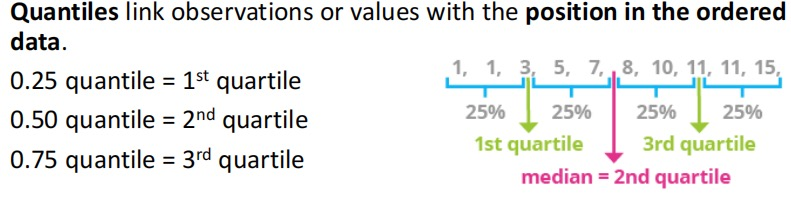

- **Sample variance(方差):** $S^{2} = \frac{1}{n-1} \sum_{i=1}^{n}(x_i - \bar{x})^2$
- **Sample standard deviation(标准差):** $S = \sqrt{S^2}$
- **Sample interquartile range(四分位距):** $IQR = 3^{rd} quartile - 1^{st} quartile$

  **Example:**

  50,100,100,250,1000
  - Sample variance S^2= $\frac{(50-300)^2 + (100-300)^2 + (100-300)^2 + (250-300)^2 + (1000-300)^2}{5-1} = 158750$
  - Sample standard deviation S = $\sqrt{s^2}= 398.4$
  - Sample interquartile range IQR = $3^{rd} quartile - 1^{st} quartile = 250 - 100 = 150$

**plot**

- **Boxplot**

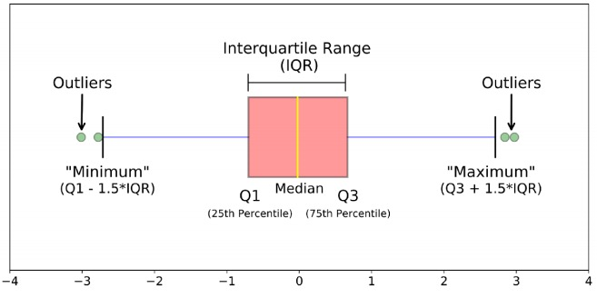

- **Q-Q(quantile-quantile) plot** 分位比较图：Quantiles 0.1,0.2,…,0.9 quantiles split the area under the density curve into ten equal areas.

Goal of the Q-Q plot:

- Compare **empirical data quantiles** with the quantiles of a **theoretical distribution**
- The ordered values are compared with the i/(n+1)-quantiles
- used to check which of two distributions describes the data better.

**Multivariate data**

## 1.2 Random Variables

### 1.2.1 Basics of probability theory

**Random variable** - Random variable X is a **function** from the **sample space** to R and represents a possible numerical outcome of an experiment. - The distribution function(**cumulative distribution function,cdf**) of a random variable X is F(x) = Fx(x) = p(X<= x), for all x

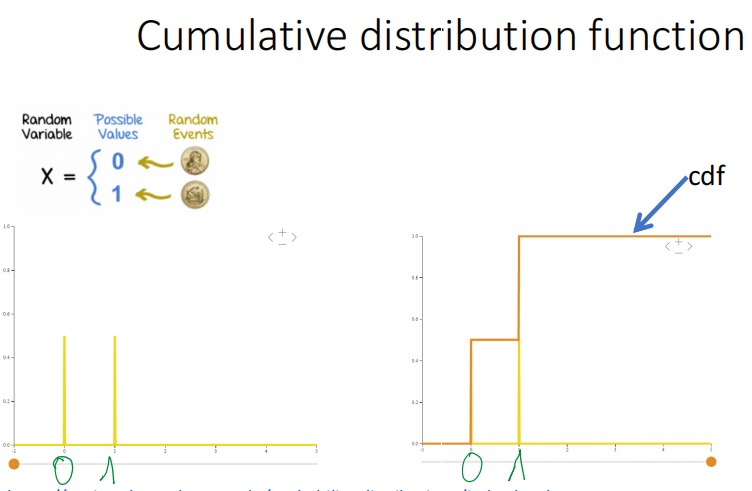

**Properties of cdf**

- Monotonically increasing: for x < y, Fx(x) <= Fx(y)
- Normalized: $\lim_{x \to -\infty} F_x(x)= 0$, $\lim_{x\to \infty} F_x(x) = 1$
- Right-continuous:$lim_{\in \to 0^+} F_x(x+ \in)= F_x(x)$ for all x $\in$ R

**Discrete distributions: Bernoulli distribution**

A random experiment with exactly two possible outcomes(for example:heads/tails) is called a **Bernoulli trial** or **Bernoulli random variable**

- P(X = 1) = p
- P(X = 0) = 1-p
- 0 < p < 1
- Bernoulli experiment is repeated n times, only the total number of success is important.X ~ Bin(n,p)
  $$P(X = k) =
  \left(\substack{n\\k}\right)p^k(1-p)^{(n-k)}, 0<p<1, k =
  0,1,...,n.$$

  **Example**

  Probability of getting 2 tails and 2 heads, when throwing 4 times a fair coin

  P(X = 2) = $\left(\substack{4\\2}\right) 0.5^2(1-0.5)^{2} = \frac{4!}{2!(4-2)!} 0.5^4 = \frac{3}{8}$

**Probability mass function(pmf)** of a **discrete random variable X** is defined by $f_X(x) = P(X = x)$

The pmf gives probabilities that the **random variables** takes a **precise single value**

**Properties of probability mass function(pmf)**

Let X be a discrete random variable with probability mass function $f_X(x)$ and cumulative distribution function $F_X(x)$. Then:

- 1. The probability mass function satisfies $f_X(x) >= 0$ for all $x \in R$
- 2. $\sum_{i} f_X(x_i) = 1$
- 3. $F_X(x) = \sum_{i:x_i<=x} f_X(x_i)$
- 4. The values $f_X(x_i) > 0$ are the “jumps” in $x_i$ of $F_X(x)$
- 5. The culmulative distribution function is a right-continuous step function

**Poisson distribution**： a random variable X, whose probability function is given by $P(X= k) = \frac{\lambda^k}{k!} exp(-\lambda)$, 0<$\lambda$, k = 0,1,… is said to follow a Poisson distribution with parameter $\lambda$, denoted by X ~ Pois($\lambda$) **在固定时间或空间内，某个事件发生的次数的离散概率分布**

**Discrete vs. Continuous distributions**

- A random variable is called **discrete** when it can assume only a **finite** or **countably infinite** number of values.
- A random variable is called **continuous** if it can assume any value from one or several intervals.

**Probability density function(pdf)$f_X(x)$** is defined by $P(a<X<=b) = \int_{a}^{b} f_X(x)dx, a<b$

**Properies of density function**

let X be a continuous random variable with density function $f_X(x)$ and distribution function $F_X(x)$,then:

- The density function satisfies $f_X(x) >= 0$ for all $x \in R$ and $f_X(x)$ is continous almost everywhere.
- $\int_{-\infty}^{\infty}f_X(x)dx = 1$
- $F_X(x) = \int_{-\infty}^{x}f_X(y)dy$
- $f_X(x) = F^{'}_X(x) = \frac{d}{dx} F_X(x)$
- The cumulative distribution function $F_X(x)$ is continous everywhere
- P(X = x) = 0

**Two conditions to check if a function is a pdf**

- $f_X(x) >= 0$
- $\int_{-\infty}^{\infty}f_X(x) = 1$

**Example**

Is $f_X(x) = \begin{cases}\frac{1}{2}x & \text{for 0<= x <= 2} \\0 &\text{otherwise}\end{cases}$ a pdf?

1. $f_X(x) >= 0$ for any x
2. $_{0}^{2}xdx = 1 $

Yes!

**Uniform distribution**

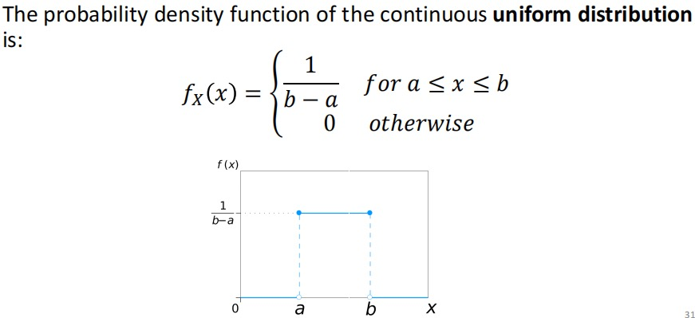

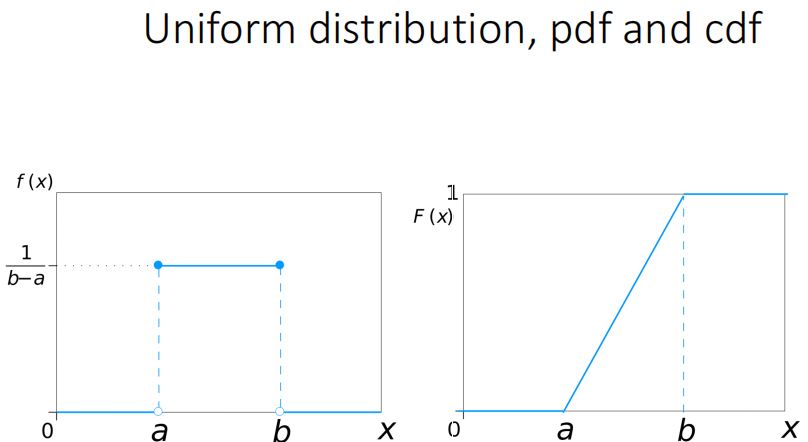

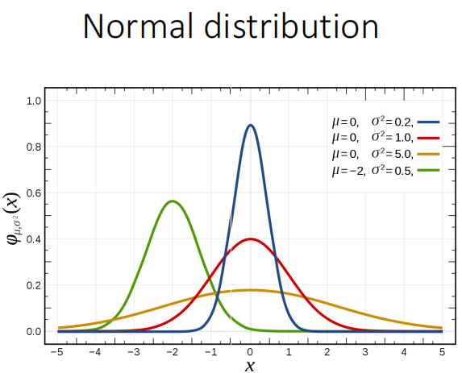

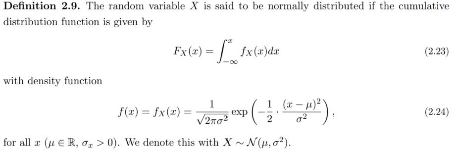

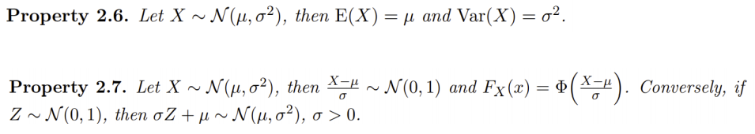

**Example**

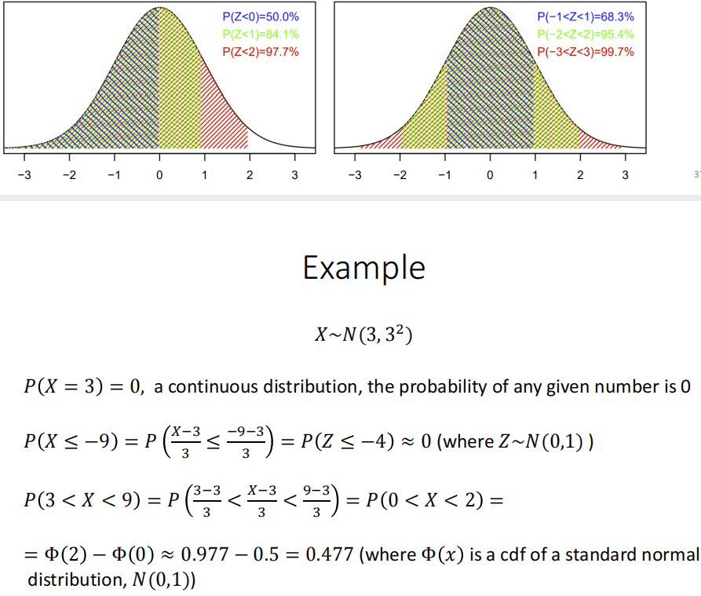

**Quantile function**

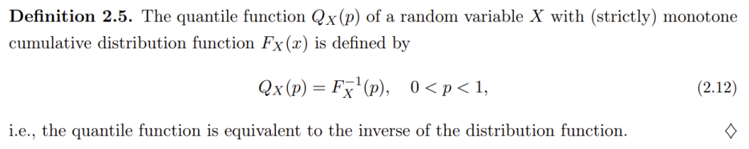

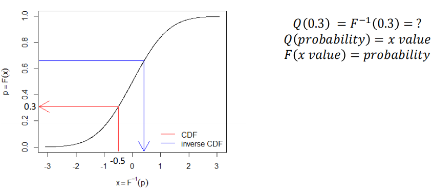

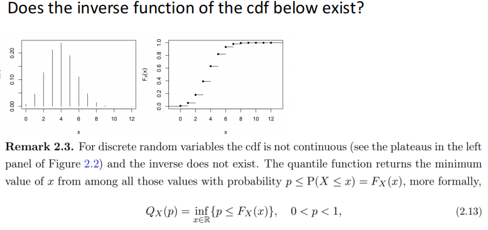

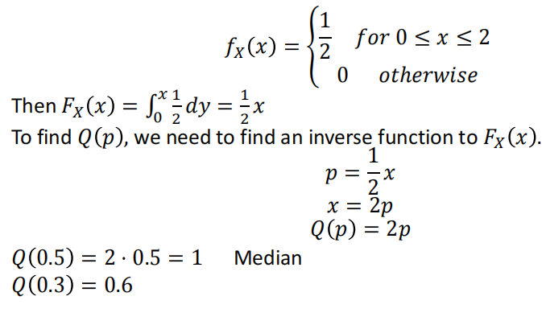

**Expectation**

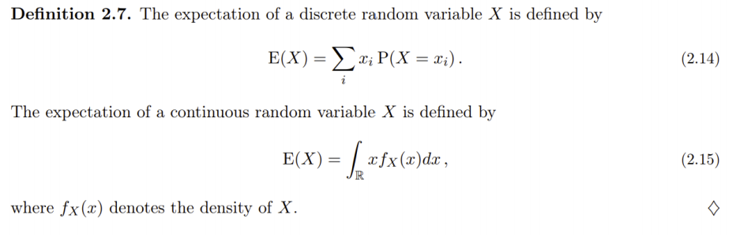

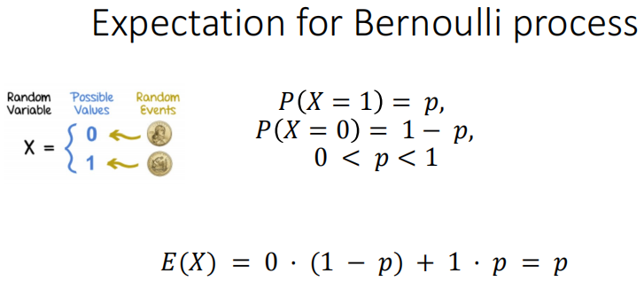

**Variance**

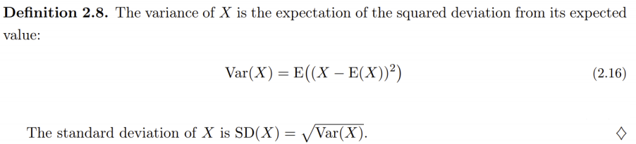

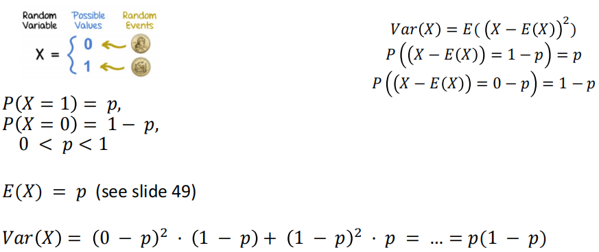

**Properties of expectation and variance**

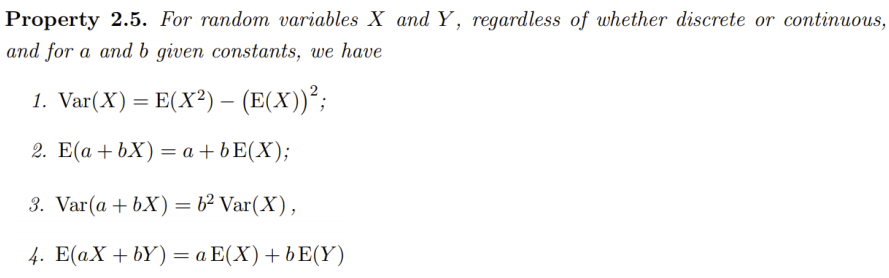

**Example**

- 1. You work 5 months in a company with an expected monthly salary $E(X) = 10k$. What would be an expected salary after 4 months of work and 5k bonus?

$E(X_{total})= 4 * E(X) + 5 = 45k$

- 2. You work 3 months in a company with an expected monthly salary $E(X) = 15k$, and 4 months in a company with an expected monthly salary $𝐸(X)=12.5𝑘$ What is your expected total salary from these 2 contracts?

contract 1: $E(X_{total}) = 3*E(X) = 45k$

contract 2: $E(X_{total}) = 4 * E(X) = 50k$

- 3. Compute expected value and variance for a die roll.

$P(X = i) = $ for i $\in$ {1,2,3,4,5,6}

$E(X) = \sum_{i= 6} ^{6} i * \frac{1}{6} = 3.5$

$Var(X) = E(X^2) - (E(X))^2 = \sum_{i=1}^{6} i^2 * \frac{1}{6} - 3.5^2 = 2\frac{11}{12}$

## 1.3 Functions of Random Variables

### 1.3.1 Independent random variables

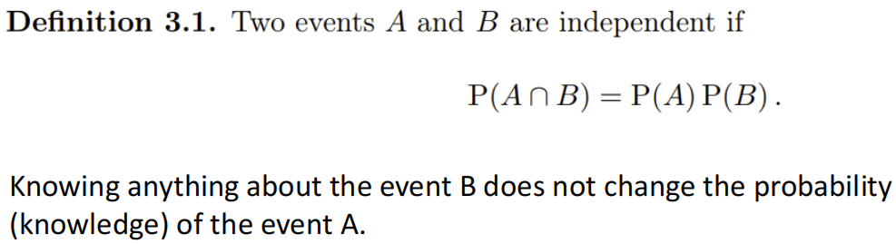

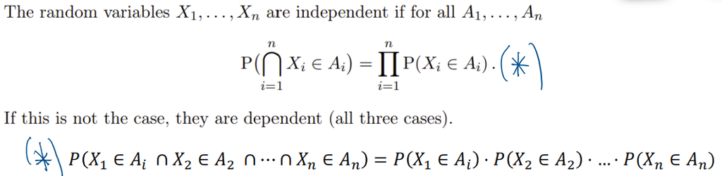

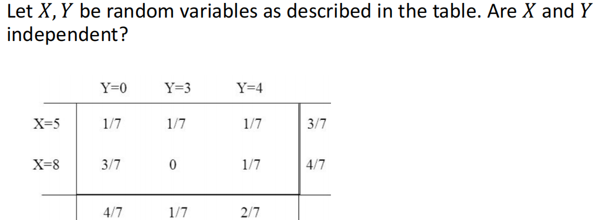

No,单独Y=0的概率和单独X=5的概率相乘 跟同时Y=0 X=5的概率不一样

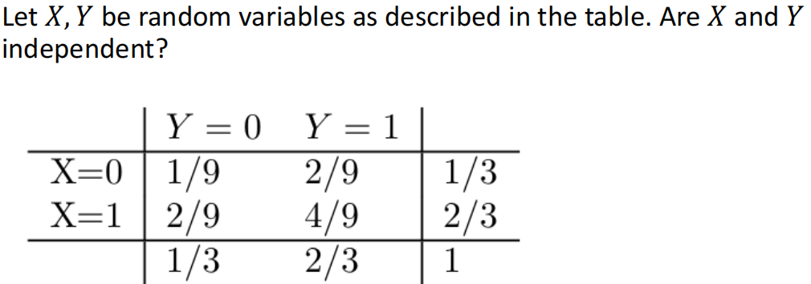

Yes

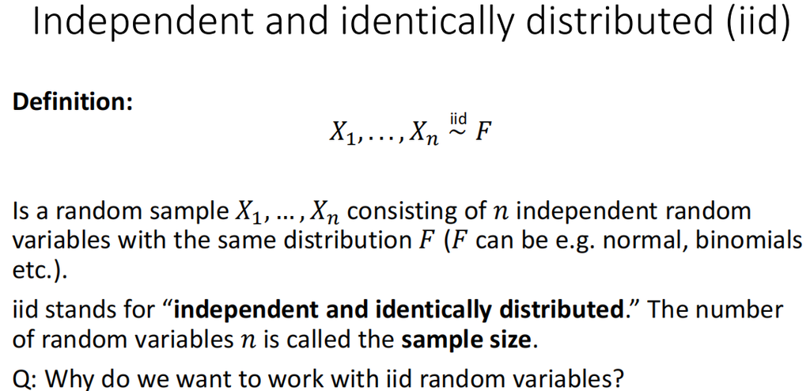

**Simplicity: When dealing with i.i.d. random variables, many statistical calculations become simpler because the assumption of independence and identical distribution allows us to treat each random variable as essentially the same.**

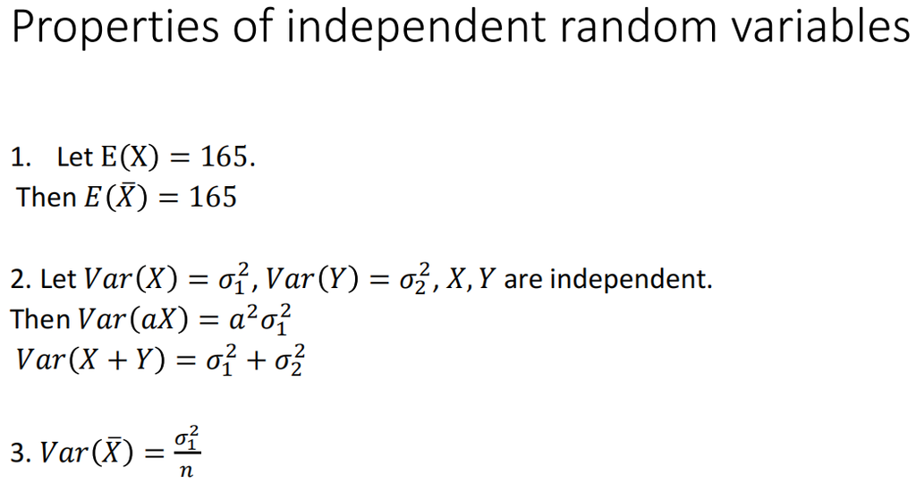

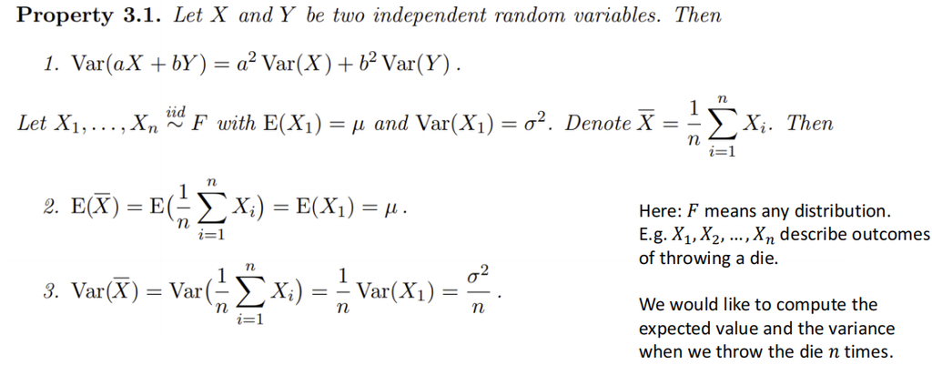

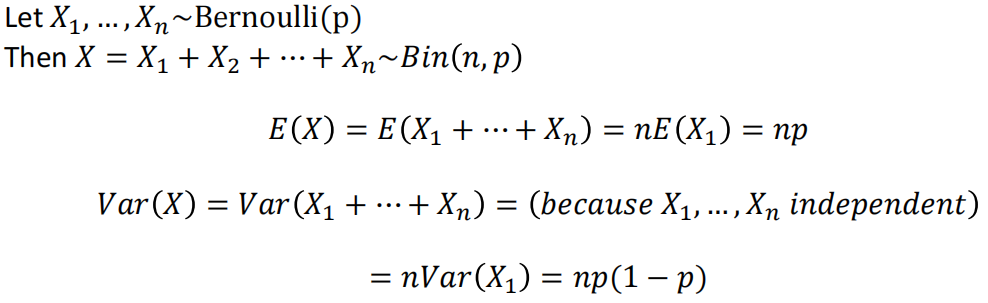

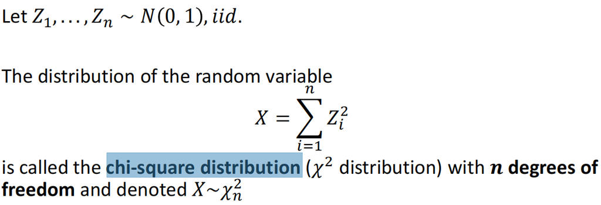

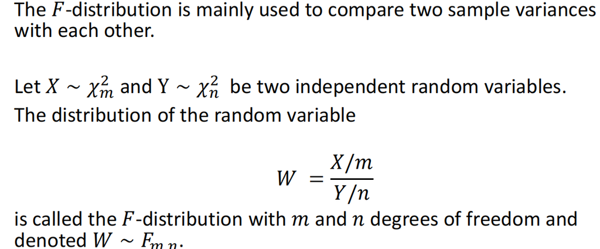

**Central limit theorem**：If you have a distribution with mean 𝜇 and standard deviation 𝜎 and take sufficiently large random samples the sample means will be approximately normally distributed

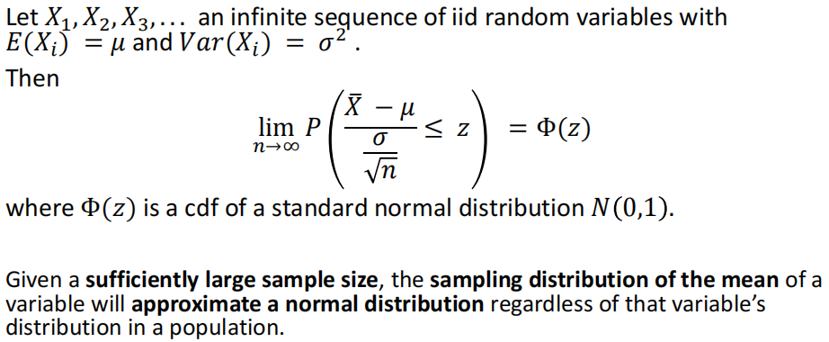

**Continuity correction**

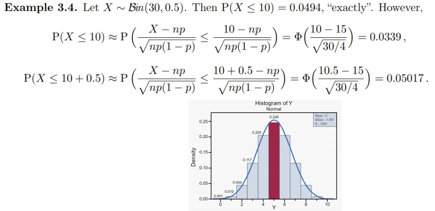

## 1.4 Multivariate Normal Distribution

# 2. Statistical Foundations

## 2.1 Estimation of Parameters

## 2.2 Statistical Testing

## 2.3 Proportions

## 2.4 Rank-Based Methods

## 2.5 Bayesian Approach

## 2.6 Monte Cario Methods

# 3. Linear Modeling

## 3.1 Correlation and Simple Regression

## 3.2 Multiple Regression

## 3.3 Analysis of Variance

## 3.4 Design of Experiments